# Bootstrap Confidence Interval

Kuei Yueh Ko

2017/3/29

# Set up Environment

import required package and set working directory

```r
library(readxl)
# set work space
workdir <- "C:\\Users\\clint\\Documents\\GitHub\\BlogDataAnalysis"
setwd(file.path(workdir, "Analysis"))

# path for data
filePathData <- file.path(
    workdir,
    "Data\\StatCompEcology\\Copepod")
```

# Set Up Functions

### Basic Functions

Function for probability distribution

```r
myUnif <- function(n, a=0, b=1) {
    # Continuous Uniform Distribution
    # Default: R.V. ~ Uniform( [0,1] )
    #====================================
    x <- runif(n)      # R.V. ~~~ Uniform( [0,1] )
    y <- x * (b-a) + a # Shift to Uniform( [a,b] )
    return(y)
} # end func myUnif
```

Function for Sampling

```r
mySample <- function(x){
    # The function is based on
    # return sample of x with replacement
    #===========================================
    # generate random numbers following uniform distribution
    n <- length(x)
    id <- myUnif(n, a=0, b=n)
    # convert continuous value into discrete
    id <- ceiling(id)
    # remove 0 (very rare case, p(X=0) is zero
    # for any continuous random variable)
    id[id==0] <- 1

    # return the result
    return(x[id])
} # end mySample
```

function to perform regression analysis

```r
RegBeta <- function(x, y){
    # Function RegBeta return the coefficient of
    # linear regression
    # x: independent variable
    # y: dependent variable
    ###################################
    # construct Design matrix
    X <- as.matrix(cbind(1, x))
    # solve by projecting to the solution space
    b <- solve(t(X) %*% X) %*% t(X) %*% y
    # return the parameters
    return(b)
} # end func RegBeta
```

### Bootstrap

Function for Bootstrapping

```r
myBootstrap <- function(x, f, N){UseMethod("myBootstrap")}

myBootstrap.data.frame <- function(x, f, N){
    print("The input data is a data.frame...")
    # get id, the idx of rows
    id  <- seq_len(nrow(x))
    # bootstrapping
    print("Performing bootstrapping...")
    val <- replicate(
        N, f(x[mySample(id),])
    ) # end replicate

    # summary statistics & return the result
    print("...Finished")
    res <- list()
    res$Val <- val       # bootstrap pedvalue
    res$MU  <- mean(val) # mean of bootstrapped value
    res$SE  <- sd(val)   # standard error of mean
    return(res)
} # end myJackknife.data.frame

myBootstrap.numeric <- function(x, f, N){
    print("The input data is a data.frame...")
    # get id, the idx of rows
    id  <- seq_len(length(x))
    # bootstrapping
    print("Performing bootstrapping...")
    val <- replicate(
        N, f(x[mySample(id)])
    ) # end replicate

    # summary statistics & return the result
    print("...Finished")
    res <- list()
    res$Val <- val       # bootstrapped value
    res$MU  <- mean(val) # mean of bootstrapped value
    res$SE  <- sd(val)   # standard error of mean
    return(res)
} # end myJackknife.numeric
```

### Jackknife

Function for Jackknife

```r
myJackknife <- function(x, f){UseMethod("myJackknife")}

myJackknife.data.frame <- function(x, f){
    print("Input is data frame")
    n  <- nrow(x)
    id <- 1:n
    matID <- sapply(
        id, function(x){id[-x]}
    ) # end sapply
    colnames(matID) <- paste0("JK", id)

    print("Performing Jackknife...")
    val <- apply(
        matID, 2,
        function(idx){
            f(
                x[idx,]
            )
        }  # end apply func
    ) # end apply

    print("...Finish")
    res <- list()
    res$MatID <- matID
    res$Val   <- val       # Jackknife value
    res$MU    <- mean(val) # mean of Jackknife value
    # standard error of mean
    res$SE    <- ((n-1) / n * sum((val-mean(val))^2))^0.5
    return(res)
} # myJackknife.data.frame

myJackknife.numeric <- function(x, f){
    print("Input is numeric vector")
    n <- length(x)
    id <- 1:n
    matID <- sapply(
        id, function(x){id[-x]}
    ) # end sapply
    colnames(matID) <- paste0("JK", id)

    print("Performing Jackknife...")
    val <- apply(
        matID, 2,
        function(idx){
            f(
                x[idx]
            )
        }  # end apply func
    ) # end apply

    print("...Finish")
    res <- list()
    res$MatID <- matID
    res$Val   <- val
    res$MU    <- mean(val)
    res$SE    <- ((n-1) / n * sum((val-mean(val))^2))^0.5
    return(res)
} # myJackknife.numeric
```

## BC Method

```r
createCDF <- function(val){
    # sort the value
    val <- sort(val)

    # create empirical CDF
    cdf <- function(x){
        prop <- mean(val <= x)
        return(prop)
    } # end inner func cdf

    # create inverse of empirical CDF
    cdfInv <- function(prop){
        idx <- round(length(val) * prop)
        x <- val[idx]
        return(x)
    } # end inner func cdfInv

    f <- list()
    f$Cdf <- cdf
    f$CdfInv <- cdfInv
    return(f)
}
```

## Bootstrap correction

Below is the formula of acceleration in BCa method

$\hat{a} = \frac{ \sum( \hat{\theta_{(.)}} - \hat{\theta_{(i)}})^3 }{ 6(\sum( \hat{\theta_{(.)}} - \hat{\theta_{(i)}})^2)^{\frac{3}{2}} }$ Function to calculate Acceleration

```r
getAcceleration <- function(val, mu){
    # difference of
    valNew = mu - val

    # numerator
    x = valNew^3
    x = sum(x)
    # denominator
    y = valNew^2
    y = sum(y)
    y = 6 * y^(3/2)
    # return result
    return(x/y)
} # end func getAcceleration
```

Correction of Bootstrap confidence interval

```r
getBStrapCI <- function(
    val, theta, alpha=0.5,
    jKnife=NULL){

    # create empirical CDF
    f  <- createCDF(val)

    # find z0 and z[alpha/2]
    g   <-  f$Cdf(theta)
    z0  <-  qnorm(g)
    zA2 <- -qnorm(alpha/2)

    # decide whether using BC or BCa
    if (!is.null(jKnife)) {
        a   <- getAcceleration(jKnife$Val, jKnife$MU)
        z2  <- z0 + (z0 + zA2) / (1 - a*(z0 + zA2))
        z1  <- z0 + (z0 - zA2) / (1 - a*(z0 - zA2))
    }else{
        a   <- NULL
        z2  <- 2 * z0 + zA2
        z1  <- 2 * z0 - zA2
    } # end ifelse

    # calculate the confidence interval
    CI <- list()
    CI$G       <- g
    CI$Z0      <- z0
    CI$Z2      <- z2
    CI$Z1      <- z1
    CI$ZAlpha2 <- zA2
    CI$Upper   <- f$CdfInv(pnorm(z2))
    CI$Lower   <- f$CdfInv(pnorm(z1))
    CI$Acceleration <- a
    return(CI)
} # end func getCI
```

# Test on Sample Data

input the test data

```r
# score of LSAT
x <- c(576, 635, 558, 578, 666, 580, 555, 661, 651, 605, 653, 575, 545, 572, 594)

# score of GPA
y <- c(3.39, 3.30, 2.81, 3.03, 3.44, 3.07, 3.00, 3.42, 3.36, 3.13, 3.12, 2.74, 2.76, 2.88, 2.96)
```

Sample Estimator

```r
# Recapitulate the data
dat <- data.frame(X=x,Y=y)

myFunc <- function(dat){
    return(cor(dat$X,dat$Y))
} # end myFunc
```

Perform Jackknife and Bootstrap analysis on test data

```r
resJKnife <- myJackknife(dat, f=myFunc)
```

```
## [1] "Input is data frame"
## [1] "Performing Jackknife..."
## [1] "...Finish"
```

```r
resBStrap <- myBootstrap(dat, f=myFunc, N=500)
```

```
## [1] "The input data is a data.frame..."
## [1] "Performing bootstrapping..."
## [1] "...Finished"
```

result of BC/BCa method

```r
# Sample Correlation
thetaHat <- myFunc(dat)

# BC method
resBC <- getBStrapCI(
    val=resBStrap$Val,
    theta=thetaHat,
    alpha = 0.1)

# BCa method
resBCa <- getBStrapCI(
    val=resBStrap$Val,
    theta=thetaHat,
    alpha = 0.1,
    jKnife=resJKnife)
```

Compare the results

```r
cat("",
    "Sample Correlation (TheltaHat):\n",
    thetaHat)
```

```
##  Sample Correlation (TheltaHat):
##  0.7752059
```

```r
cat("",
    "BC Method", "\n",
    "  G(ThetaHat):", resBC$G,      "\n",
    "  Z0:         ", resBC$Z0,     "\n",
    "  Z[Alpha/2]: ", resBC$ZAlpha2,"\n",
    "  Z2:         ", resBC$Z2,     "\n",
    "  Z1:         ", resBC$Z1,     "\n",
    "Upper Bound:  ", resBC$Upper,  "\n",
    "Lower Bound:  ", resBC$Lower,  "\n")
```

```
##  BC Method
##    G(ThetaHat): 0.458
##    Z0:          -0.1054736
##    Z[Alpha/2]:  1.644854
##    Z2:          1.433906
##    Z1:          -1.855801
##  Upper Bound:   0.9395076
##  Lower Bound:   0.4854324
```

```r
cat("",
    "BCa Method\n",
    "Upper Bound:  ", resBCa$Upper, "\n",
    "Lower Bound:  ", resBCa$Lower, "\n",
    "Acceleration: ", resBCa$Acceleration)
```

```
##  BCa Method
##  Upper Bound:   0.9265939
##  Lower Bound:   0.3965961
##  Acceleration:  -0.07645636
```

# Q1

### Read in the data

- copepod density (cpodDens)
- fish density (fishDens)

```r
# read in data from excel file
dat <- read_excel(
    file.path(filePathData, "enviANDdensity.xls"),
    sheet=1)
#head(dat)

# get the density of fish and copepod
fishDens <- dat$`FishDensity (ind./1000m3)`
cpodDens <- dat$`CopepodDensity ind./m3)`
```

### Summary Statistics

calculate and store the statistics of densities  
(Mean, Standard deviation, Median, and Standard Error of Mean)

```r
# copepod densities
res <- list()
res$Val    <- cpodDens
res$Mean   <- mean(res$Val)
res$SD     <- sd(res$Val)
res$SE     <- res$SD/length(res$Val)^0.5
res$Median <- median(res$Val)
cpod <- res

# fish densities
res <- list()
res$Val    <- fishDens
res$Mean   <- mean(res$Val)
res$SD     <- sd(res$Val)
res$SE     <- res$SD/length(res$Val)^0.5
res$Median <- median(res$Val)
fish <- res
########################
cat("",
    "Mean of Copepod Density", cpod$Mean, "\n",
    "SE   of Copepod Density", cpod$SE,   "\n",
    "Mean of Fish    Density", fish$Mean, "\n",
    "SE   of Fish    Density", fish$SE)
```

```
##  Mean of Copepod Density 1972.374
##  SE   of Copepod Density 342.5549
##  Mean of Fish    Density 322.4516
##  SE   of Fish    Density 61.23107
```

Sample Estimator

```r
# Encapitulate the data
dat <- data.frame(X=cpod$Val,Y=fish$Val)

# encapsulate the function
myFunc <- function(dat){
    # the function input a data.frame, which contains two column X and Y
    # perform the linear regression and acquire the coefficients
    res <- RegBeta(x=dat$X, y=dat$Y)
    return(as.vector(res))
} # end myFunc
```

Perform Jackknife analysis

```r
jKnife_Beta <- myJackknife(dat, f=myFunc)
```

```
## [1] "Input is data frame"
## [1] "Performing Jackknife..."
## [1] "...Finish"
```

```r
n <- nrow(dat)

res <- list()
val <- jKnife_Beta$Val[1,]
res$Val   <- val
res$MU    <- mean(val)
res$SE    <- ((n-1) / n * sum((val-mean(val))^2))^0.5
jKnife_Beta0 <- res

res <- list()
val <- jKnife_Beta$Val[2,]
res$Val   <- val
res$MU    <- mean(val)
res$SE    <- ((n-1) / n * sum((val-mean(val))^2))^0.5
jKnife_Beta1 <- res
```

Perform Bootstrap analysis

```r
bStrap_Beta <- myBootstrap(dat, f=myFunc, N=100)
```

```
## [1] "The input data is a data.frame..."
## [1] "Performing bootstrapping..."
## [1] "...Finished"
```

```r
res <- list()
val <- bStrap_Beta$Val[1,]
res$Val   <- val
res$MU    <- mean(val)
res$SE    <- sd(val)
bStrap_Beta0 <- res

res <- list()
val <- bStrap_Beta$Val[2,]
res$Val   <- val
res$MU    <- mean(val)
res$SE    <- sd(val)
bStrap_Beta1 <- res
```

result of BC/BCa method

```r
# Sample regression
BetaHat <- myFunc(dat)

# BC method
resBC_Beta0 <- getBStrapCI(
    val=bStrap_Beta0$Val,
    theta=BetaHat[1],
    alpha = 0.05)

resBC_Beta1 <- getBStrapCI(
    val=bStrap_Beta1$Val,
    theta=BetaHat[2],
    alpha = 0.05)

# BCa method
resBCa_Beta0 <- getBStrapCI(
    val=bStrap_Beta0$Val,
    theta=BetaHat[1],
    alpha = 0.05,
    jKnife=jKnife_Beta0)

resBCa_Beta1 <- getBStrapCI(
    val=bStrap_Beta1$Val,
    theta=BetaHat[2],
    alpha = 0.05,
    jKnife=jKnife_Beta1)
```

Compare the results

```r
cat("",
    "Regression:\n",
    "  Beta0: ", BetaHat[1], "\n",
    "  Beta1: ", BetaHat[2], "\n")
```

```
##  Regression:
##    Beta0:  93.06466
##    Beta1:  0.1162999
```

```r
cat("",
    "BC Method", "\n",
    "Upper Bound:  ", resBC_Beta0$Upper,  "\n",
    "Lower Bound:  ", resBC_Beta0$Lower,  "\n")
```

```
##  BC Method
##  Upper Bound:   226.807
##  Lower Bound:   -14.30348
```

```r
cat("",
    "BC Method", "\n",
    "Upper Bound:  ", resBC_Beta1$Upper,  "\n",
    "Lower Bound:  ", resBC_Beta1$Lower,  "\n")
```

```
##  BC Method
##  Upper Bound:   0.1794722
##  Lower Bound:   0.06687916
```

```r
cat("",
    "BCa Method\n",
    "Upper Bound:  ", resBCa_Beta0$Upper, "\n",
    "Lower Bound:  ", resBCa_Beta0$Lower, "\n",
    "Acceleration: ", resBCa_Beta0$Acceleration)
```

```
##  BCa Method
##  Upper Bound:   228.0895
##  Lower Bound:   -12.61469
##  Acceleration:  0.06086727
```

```r
cat("",
    "BCa Method\n",
    "Upper Bound:  ", resBCa_Beta1$Upper, "\n",
    "Lower Bound:  ", resBCa_Beta1$Lower, "\n",
    "Acceleration: ", resBCa_Beta1$Acceleration)
```

```
##  BCa Method
##  Upper Bound:   0.1749885
##  Lower Bound:   0.05946465
##  Acceleration:  -0.1027437
```

# Q2

```r
filePathData <- file.path(
    workdir,"Data","StatCompEcology","Copepod")

cPodDensity <- read.table(file.path(
    filePathData, "cop_density.txt"),
    header=T)

cPodCompose <- read.table(file.path(
    filePathData, "copepod_composition.txt"),
    header=T)

cpodSpecies <- read.delim(file.path(
    filePathData, "copepodSPlist.txt"),
    header=F)

rownames(cPodCompose) <- cpodSpecies[[1]]
head(cPodCompose)
```

```
##                    p1 p3 p4 p6 p13  p16  p19 p21  p23  p25  s18  s19  s20
## Acartia bifilosa    0  0  0  0   0 0.00 0.00   0 0.00 0.00 0.00 0.00 0.00
## Acartia erythraea   0  0  0  0   0 0.00 0.00   0 0.00 0.00 0.00 0.00 0.00
## Acartia negligence  0  0  0  0   0 0.22 2.34   0 2.51 1.62 0.00 0.00 0.00
## Acartia omori       0  0  0  0   0 0.00 0.00   0 0.00 0.00 0.00 0.00 0.00
## Acartia pacifica    0  0  0  0   0 0.00 0.00   0 0.00 0.00 4.07 1.56 1.08
## Acartia sp          0  0  0  0   0 0.00 0.00   0 0.00 0.00 0.00 0.00 0.00
##                     s22  s23  s25  s27  s29   sA   sB   sC   sD   sE   sF
## Acartia bifilosa   0.00 0.00 0.30 0.00 0.00 0.00 0.00 0.00 0.00 0.00 0.00
## Acartia erythraea  0.00 0.00 0.00 0.00 0.00 0.00 0.00 0.00 0.00 0.00 0.00
## Acartia negligence 0.00 0.00 0.00 1.52 0.30 3.06 1.35 1.24 0.62 2.92 0.31
## Acartia omori      0.00 0.00 0.00 0.00 0.00 0.26 0.00 0.00 0.00 0.00 0.00
## Acartia pacifica   4.83 8.49 1.49 0.00 0.00 0.26 0.00 0.00 0.00 0.32 1.53
## Acartia sp         0.00 0.00 0.00 0.76 1.51 0.00 0.00 0.00 0.00 0.00 0.00
##                     sG   w22   w23  w25  w27  w29   wA   wB   wC   wD
## Acartia bifilosa   0.0  0.00  0.00 0.00 0.00 0.00 0.00 0.00 0.00 0.00
## Acartia erythraea  0.0  0.00  0.00 0.00 0.00 0.42 0.00 0.00 0.00 0.00
## Acartia negligence 1.4  0.00  0.00 0.00 0.00 0.00 0.00 2.22 1.13 0.93
## Acartia omori      0.0  0.00  0.00 0.00 0.00 0.00 0.00 0.00 0.00 0.00
## Acartia pacifica   0.0 19.42 51.76 2.81 3.85 6.28 0.55 0.28 0.00 0.62
## Acartia sp         0.0  0.00  0.00 0.00 0.00 0.00 0.00 0.00 0.00 0.00
```

calculate the density of each copepod in 34 stations

```r
dat <- cPodCompose / 100

# multiple total density to each row of matrix
res <- apply(
    dat, 1,
    function(x){x * cPodDensity[,1]})
res <- t(res)
```

extract the data of species Oncaea venusta and Canthocalanus pauper

```r
dat <- res[
    c("Oncaea venusta",
      "Canthocalanus pauper"),]
```

Perform bootstrap

```r
# sample difference
thetaHat <- mean(dat[1,] - dat[2,])

# Bootstrap
val <-
    sample(dat[1,], 500, replace = TRUE) -
    sample(dat[2,], 500, replace = TRUE)
bStrap_DiffVal <- list()
bStrap_DiffVal$Val <- val
bStrap_DiffVal$MU  <- mean(val)
```

plot the distribution

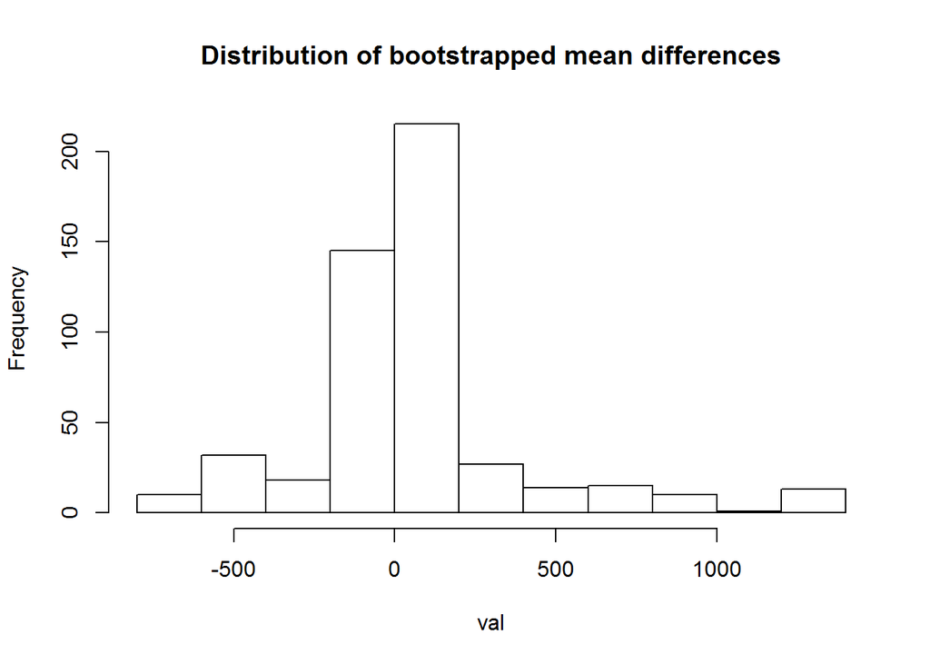

```r
hist(val, main="Distribution of bootstrapped mean differences")
```

get CI with BC method

```r
resBC <- getBStrapCI(
    bStrap_DiffVal$Val,
    theta=thetaHat,
    alpha = 0.05)

cat("",
    "BC Method", "\n",
    "Upper Bound:  ", resBC_Beta1$Upper,  "\n",
    "Lower Bound:  ", resBC_Beta1$Lower,  "\n")
```

```
##  BC Method
##  Upper Bound:   0.1794722
##  Lower Bound:   0.06687916
```